# Presidential campaigns

Pragya Jha

December 16, 2017

# Introduction

This is an exploration of 2016 US presidential campaign donations in the state of Texas. For this exploration data analysis, I am researching the 2016 presidential campaign finance data from Federal Election Commission. The dataset contains financial contribution transaction till 2016.

```
## [1] 548396     18
```

```
## 'data.frame':    548396 obs. of  18 variables:
##  $ cmte_id          : Factor w/ 26 levels "C00458844","C00496034",..: 7 16 16 8 7 7 16 16 7 16 ...
##  $ cand_id          : Factor w/ 25 levels "P00003392","P20002671",..: 1 23 23 12 1 1 23 23 1 23 ...
##  $ cand_nm          : Factor w/ 25 levels "Bush, Jeb","Carson, Benjamin S.",..: 4 23 23 20 4 4 23 23 4 23 ...
##  $ contbr_nm        : Factor w/ 129927 levels "'CALL, JANE",..: 78846 104629 104633 67432 47336 126503 99534 93791 58977 93812 ...
##  $ contbr_city      : Factor w/ 2252 levels "","-2111",". FREEPORT.       PAY FOR EMPL",..: 427 699 2200 1474 1802 116 1858 965 1918 1248 ...
##  $ contbr_st        : Factor w/ 1 level "TX": 1 1 1 1 1 1 1 1 1 1 ...
##  $ contbr_zip       : Factor w/ 66331 levels "","0","1020",..: 50056 18335 32874 19905 48356 57005 45705 32932 17809 17198 ...
##  $ contbr_employer  : Factor w/ 40164 levels "","'CALL PHONOGRAPH LLC",..: 24038 3596 28912 24933 6082 9778 17644 17644 8244 30753 ...
##  $ contbr_occupation: Factor w/ 17467 levels "","-"," CERTIFIED REGISTERED NURSE ANESTHETIS",..: 13568 13238 13568 10154 14388 14007 7704 7704 11436 7239 ...
##  $ contb_receipt_amt: num  37.1 127.1 80 15 50 ...
##  $ contb_receipt_dt : Factor w/ 746 levels "1-Apr-15","1-Apr-16",..: 168 514 6 665 724 605 534 582 317 624 ...
##  $ receipt_desc     : Factor w/ 61 levels "","* EARMARKED CONTRIBUTION: SEE BELOW REATTRIBUTION/REFUND PENDING",..: 1 1 1 1 1 1 1 1 1 1 ...
##  $ memo_cd          : Factor w/ 2 levels "","X": 2 2 2 1 2 2 2 2 2 2 ...
##  $ memo_text        : Factor w/ 291 levels "","$0.10 REFUNDED ON 10/24/2016",..: 40 1 1 31 40 40 1 1 40 1 ...
##  $ form_tp          : Factor w/ 3 levels "SA17A","SA18",..: 2 2 2 1 2 2 2 2 2 2 ...
##  $ file_num         : int  1091718 1146165 1146165 1077404 1091718 1091718 1146165 1146165 1091718 1146165 ...
##  $ tran_id          : Factor w/ 543825 levels "A0009C127D0D344E3885",..: 139500 461349 403810 493948 139256 139041 429428 400817 139706 461688 ...
##  $ election_tp      : Factor w/ 5 levels "","G2016","O2016",..: 5 2 2 5 5 5 2 2 5 2 ...
```

This dataset contains 548396 contributions and 18 variables. To start, I want to have a glance how the contribution distributed.

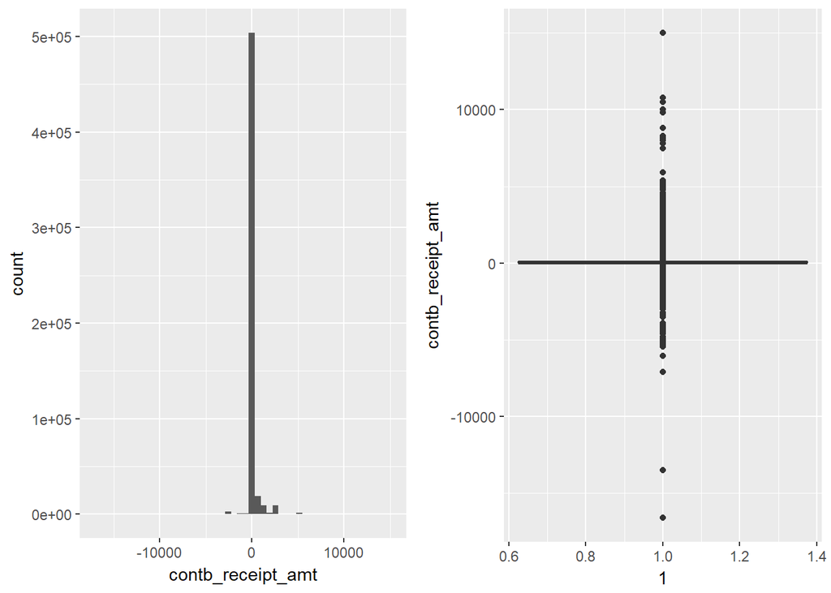

I realized that there were so many outliers(extreme high and extreme low values), it was impossible to see details. And there were negative contributions too.

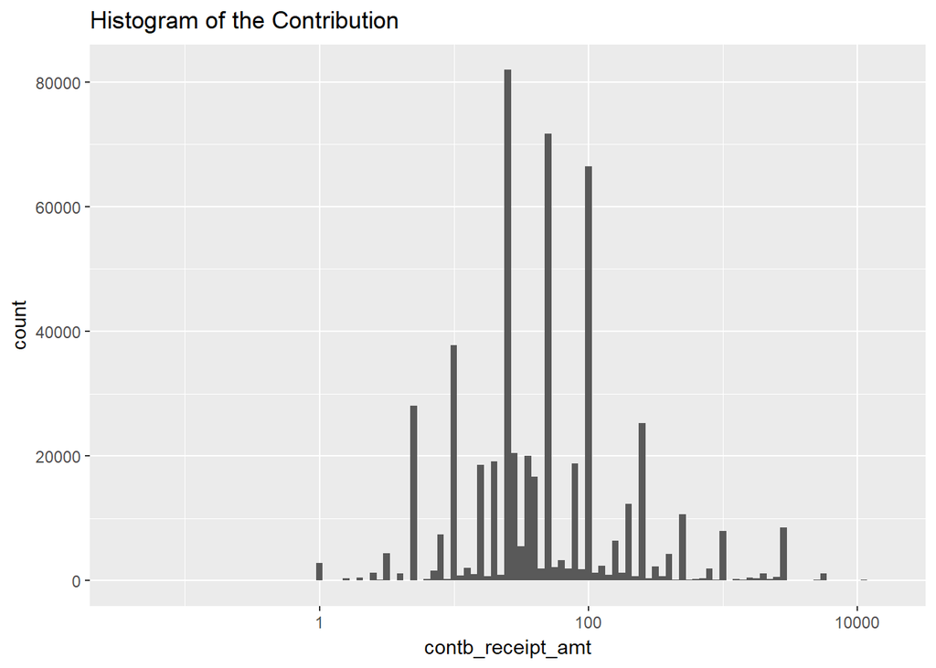

```
##
##     5    10   100    50    25
## 28008 37692 65084 69794 80376
```

```
##     Min.  1st Qu.   Median     Mean  3rd Qu.     Max.
## -16600.0     20.0     38.0    138.2    100.0  15000.0
```

Transforming to log10 to better understand the distribution of the contribution. The distribution looks normal and the data illustrated that most donors made small amount of contributions.

```
## [1] 10093
```

```
## [1] 12084
```

I will need to add more variables such as candidate party affiliate, donors’ gender and donors’ zipcodes.

The additional variables are:

-party: candidates party affilliation. -contbr_first_nm: contributor’s first name will be used to predict gender. -gender: contributor’s gender. -Latitude: Donor’s latitude for map creation. -Longitute: Donor’s longitude for map creation.

After adding the variables, I wonder what the contribution distribution looks like across the parties, candidates, genders and occupations.

```
## # A tibble: 3 x 5
##        party sum_party number_of_candidate mean_party      n
##        <chr>     <dbl>               <int>      <dbl>  <int>
## 1   democrat  25422745                   5  5084549.0 271863
## 2     others    442253                   3   147417.7   1836
## 3 republican  47340419                  17  2784730.6 243948
```

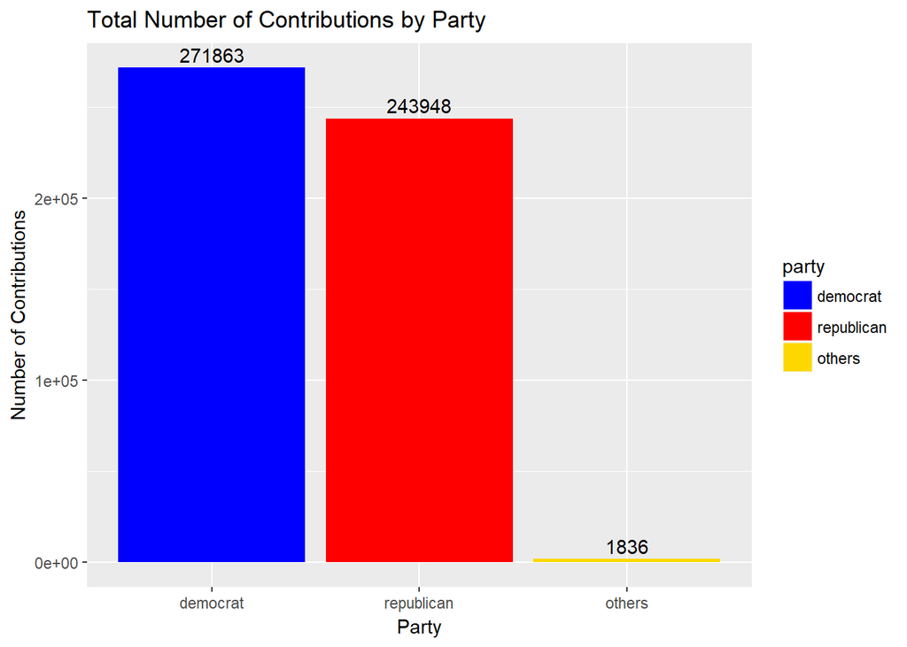

```
## [1] 517647
```

Until November, 2016, total number of donations made to the presidential election near 515K, and the Democratic party took more than 250K.

```
##
##                 Bush, Jeb       Carson, Benjamin S.
##                      3160                     22471
##  Christie, Christopher J.   Clinton, Hillary Rodham
##                       188                    194289
## Cruz, Rafael Edward 'Ted'            Fiorina, Carly
##                    127925                      2438
##      Gilmore, James S III        Graham, Lindsey O.
##                         5                       147
##            Huckabee, Mike             Jindal, Bobby
##                       705                        55
##             Johnson, Gary           Kasich, John R.
##                      1309                      1158
##          Lessig, Lawrence            McMullin, Evan
##                        31                       191
##   O'Malley, Martin Joseph         Pataki, George E.
##                       208                         9
##                Paul, Rand    Perry, James R. (Rick)
##                      2943                       547
##              Rubio, Marco          Sanders, Bernard
##                      8095                     77278
##      Santorum, Richard J.               Stein, Jill
##                       244                       336
##          Trump, Donald J.             Walker, Scott
##                     73443                       415
##     Webb, James Henry Jr.
##                        57
```

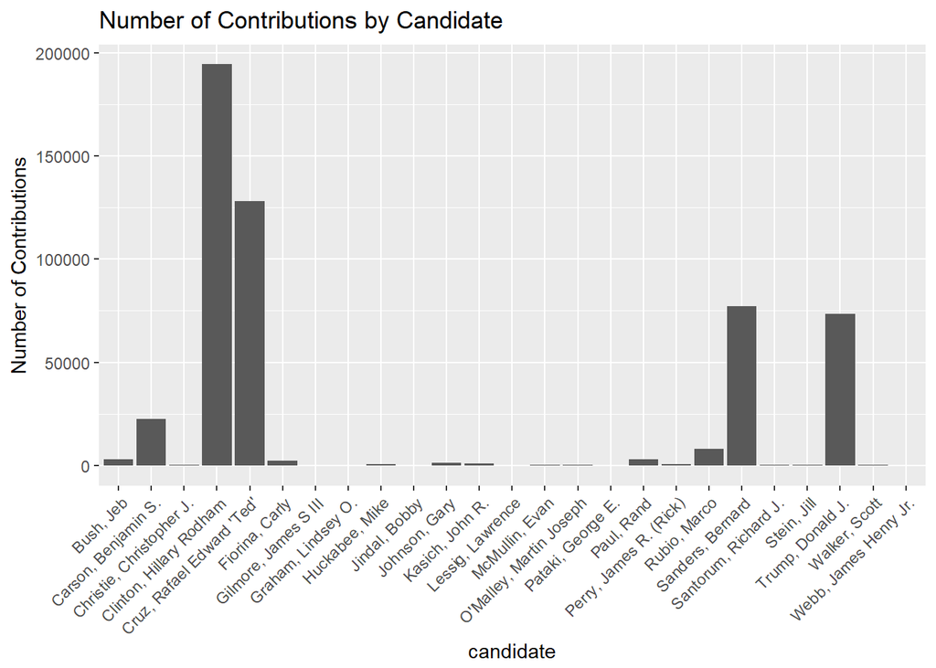

There were total 25 candidates, Hillary Clinton was the leader in the number of contributions, followed by Rafael Edward, then Bernard Sanders and then Donald Trump.

```
## # A tibble: 2 x 3
##   gender  sum_gen  n_gen
##    <chr>    <dbl>  <int>
## 1 female 29100036 243640
## 2   male 44105382 274007
```

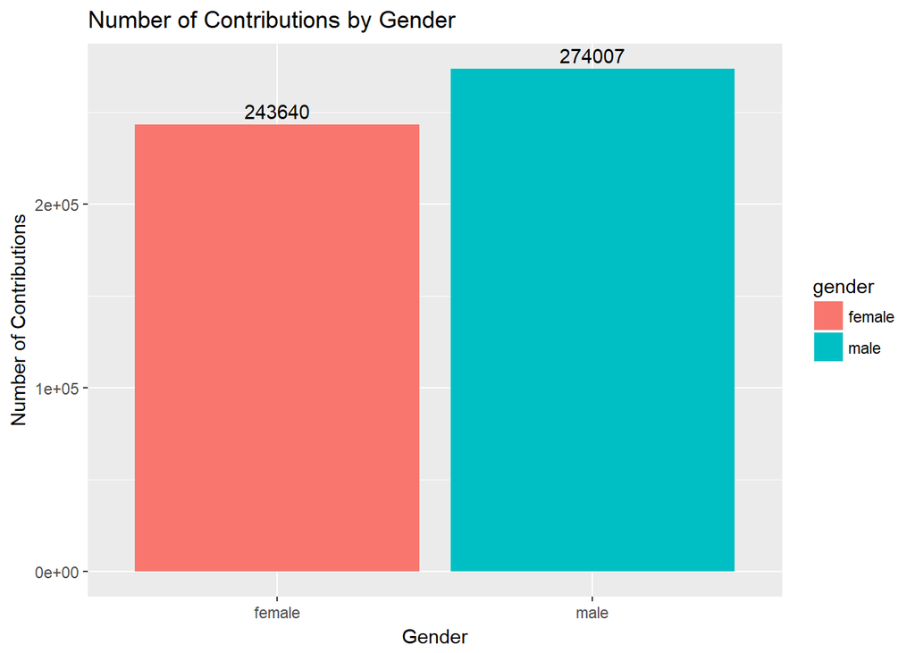

Who are those donors?

```
## # A tibble: 10 x 4
##    contbr_occupation   sum_occu mean_occu      n
##               <fctr>      <dbl>     <dbl>  <int>
##  1           RETIRED 14463581.2 106.39758 135939
##  2      NOT EMPLOYED  1115695.9  49.29074  22635
##  3          ATTORNEY  3970684.4 293.77659  13516
##  4         HOMEMAKER  3396748.8 327.93482  10358
##  5          ENGINEER  1178075.9 138.85855   8484
##  6         PHYSICIAN  1935789.1 244.63404   7913
##  7           TEACHER   445565.3  57.61123   7734
##  8             SALES   717011.8 105.16454   6818
##  9        CONSULTANT   935606.1 179.92425   5200
## 10         PROFESSOR   470172.9  97.62726   4816
```

```
## # A tibble: 10 x 4
##    contbr_occupation   sum_occu mean_occu      n
##                <ord>      <dbl>     <dbl>  <int>
##  1           RETIRED 14463581.2 106.39758 135939
##  2      NOT EMPLOYED  1115695.9  49.29074  22635
##  3          ATTORNEY  3970684.4 293.77659  13516
##  4         HOMEMAKER  3396748.8 327.93482  10358
##  5          ENGINEER  1178075.9 138.85855   8484
##  6         PHYSICIAN  1935789.1 244.63404   7913
##  7           TEACHER   445565.3  57.61123   7734
##  8             SALES   717011.8 105.16454   6818
##  9        CONSULTANT   935606.1 179.92425   5200
## 10         PROFESSOR   470172.9  97.62726   4816
```

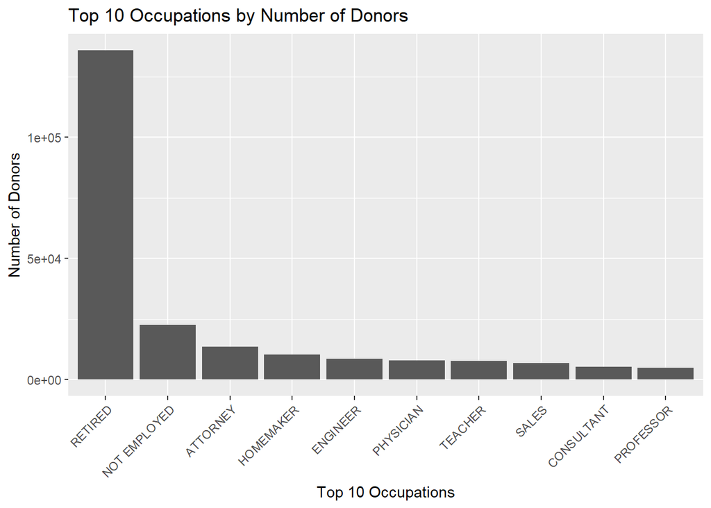

When we count the number of donors, retired people take the first place, followed by not employed people, attorney comes to the third, consultant and professor are among the least in terms of number of contributions.

```
##         Min.      1st Qu.       Median         Mean      3rd Qu.
## "2013-10-21" "2016-02-07" "2016-04-29" "2016-04-27" "2016-08-12"
##         Max.
## "2016-12-31"
```

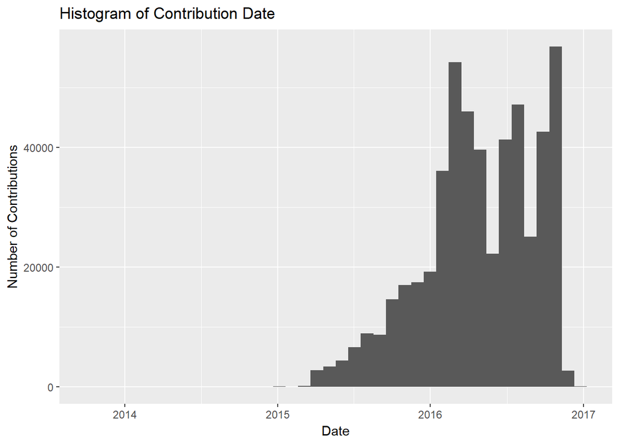

# Univariate Analysis

## What is the structure of your dataset?

There are 517647 contributions and 18 variables. The variables that interest to me and I will be using are:

-cand_nm: Candidate Name -contbr_zip: Contributor Zipcode -contbr_nm: Contributor name (first name in particular) -contbr_occupation: Contributor Occupation -contb_receipt_amt: Contribution Amount -contb_receipt_dt: Contribution date Other observations:

Most people contribute small amount of money.

The democratic party receive the most number of donations. Hillary Clinton have the most supporters.

Retired people make the most number of contributions.

## What other features in the dataset do you think will help support your investigation into your feature(s) of interest?

Gender, occupation, time of the contribution, location are likely contribute to the contribution amount and contribution party. I think occupation probably contributes most to the average contribution amount, and gender probably contributes most to the contribution party.

## Did you create any new variables from existing variables in the dataset?

I created 5 variables:

-party: candidates party affilliation. -contbr_first_nm: contributor’s first name will be used to predict gender. -gender: contributor’s gender. -Latitude: Donor’s latitude for map creation. -Longitute: Donor’s longitude for map creation.

Of the features you investigated, were there any unusual distributions? Did you perform any operations on the data to tidy, adjust, or change the form of the data? If so, why did you do this?

I omitted negative contributions because I believe they were refund, and I omitted contributions that exceed $2700 because because it breaks Federal Election Campaign Act and will be refunded.

# Bivariate plots

```
## # A tibble: 3 x 5
##        party sum_party number_of_candidate mean_party      n
##        <ord>     <dbl>               <int>      <dbl>  <int>
## 1   democrat  25422745                   5  5084549.0 271863
## 2     others    442253                   3   147417.7   1836
## 3 republican  47340419                  17  2784730.6 243948
```

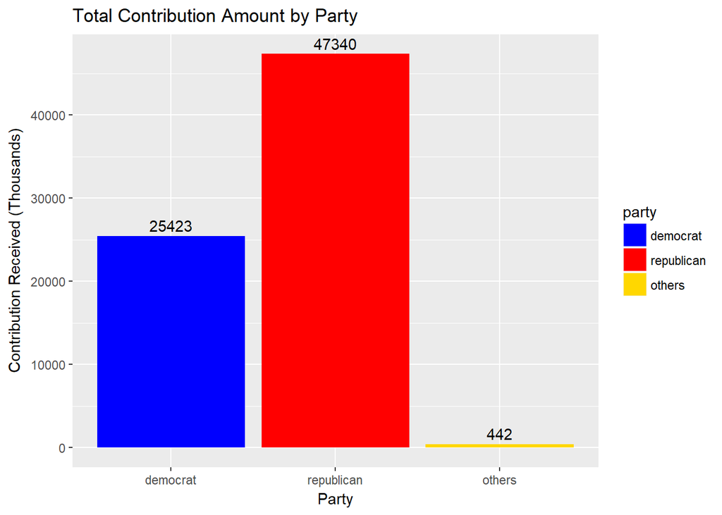

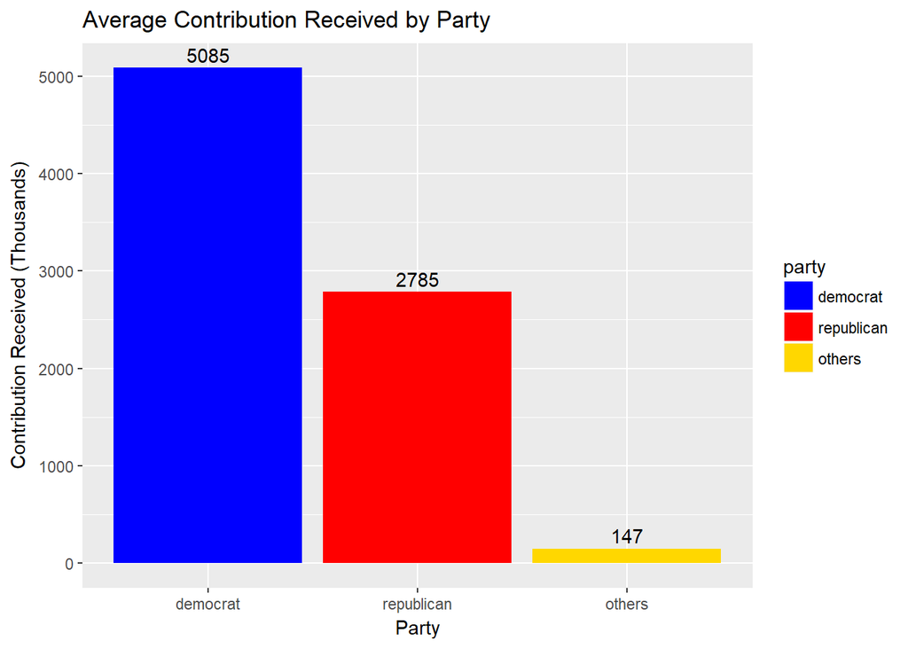

```
## ptx$cand_nm
##         Pataki, George E.      Gilmore, James S III
##                   6000.00                  11800.00
##          Lessig, Lawrence     Webb, James Henry Jr.
##                  20027.94                  31090.16
##            McMullin, Evan             Jindal, Bobby
##                  37237.00                  42460.00
##               Stein, Jill   O'Malley, Martin Joseph
##                  86921.17                 139187.00
##        Graham, Lindsey O.  Christie, Christopher J.
##                 146487.00                 269355.00
##      Santorum, Richard J.            Huckabee, Mike
##                 281288.20                 284820.76
##             Johnson, Gary             Walker, Scott
##                 318094.81                 365142.00
##           Kasich, John R.            Fiorina, Carly
##                 516021.00                 607165.56
##                Paul, Rand    Perry, James R. (Rick)
##                 675935.24                 750595.16
##       Carson, Benjamin S.              Rubio, Marco
##                3049869.53                3183709.15
##          Sanders, Bernard                 Bush, Jeb
##                3433576.71                3562397.09
##          Trump, Donald J. Cruz, Rafael Edward 'Ted'
##               15291369.12               18296004.64
##   Clinton, Hillary Rodham
##               21798863.28
```

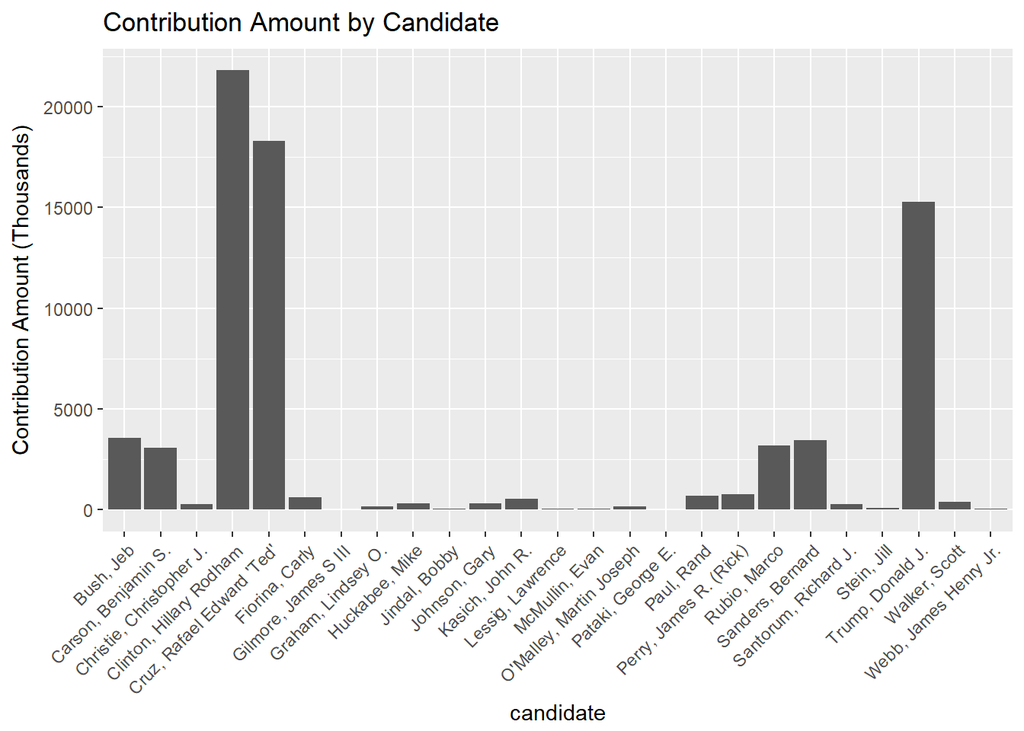

```
## [1] 73205418
```

To see contribution patterns between parties and candidates, I start with boxplots.

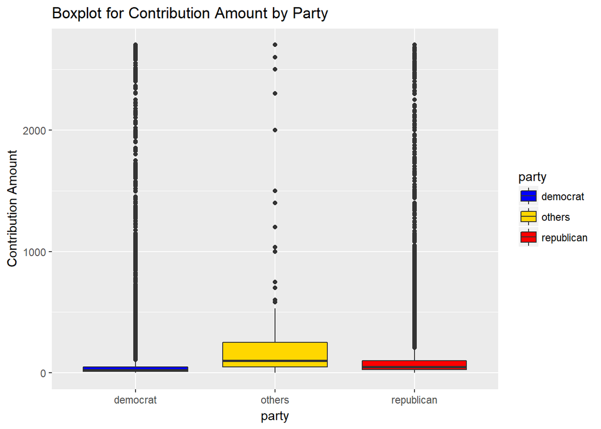

However, it is very hard to compare contributions among all parties at a glance because there are so many outliers. I will apply log scale and remove the ‘others’ party from now on because my analysis is focused on the Democratic party and the Republican party.

```
## ptx$party: democrat
##    Min. 1st Qu.  Median    Mean 3rd Qu.    Max.
##    0.04   11.00   25.00   93.51   50.00 2700.00
## --------------------------------------------------------
## ptx$party: republican
##    Min. 1st Qu.  Median    Mean 3rd Qu.    Max.
##     0.5    28.0    50.0   194.1   100.0  2700.0
```

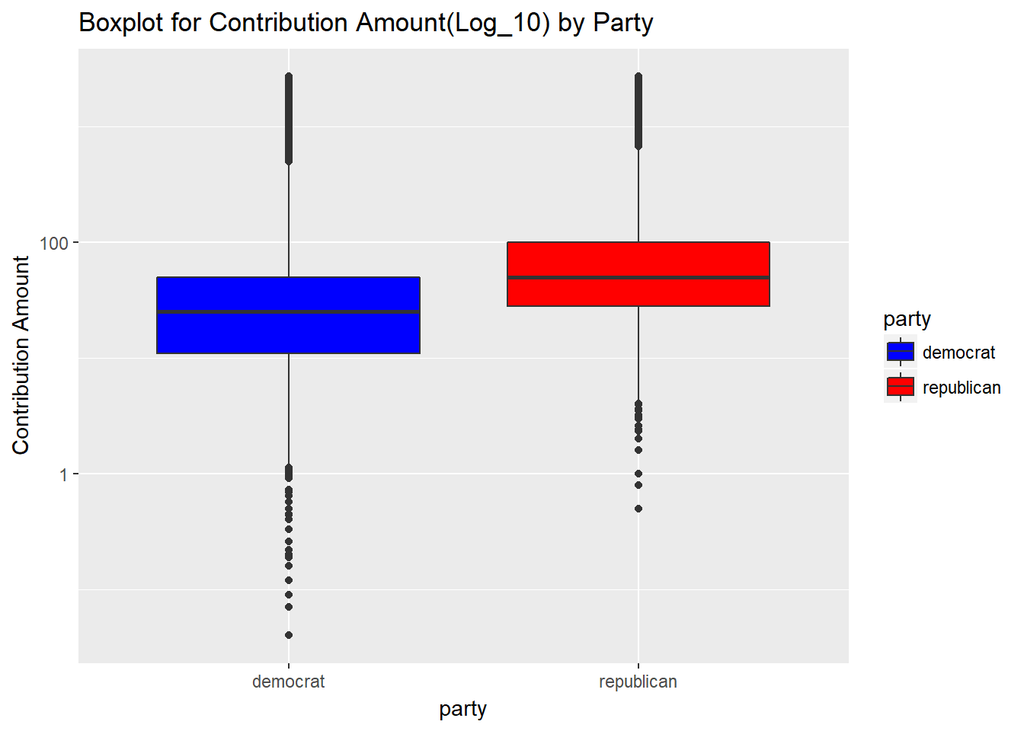

Now it is much better. Although the Republican has the higher median and mean, the Democrat has more variations and the distribution is more spread out. This indicates that the Democrat has more big and small donors.

```
## ptx$cand_nm: Bush, Jeb
##    Min. 1st Qu.  Median    Mean 3rd Qu.    Max.
##       1     100     500    1127    2700    2700
## --------------------------------------------------------
## ptx$cand_nm: Carson, Benjamin S.
##    Min. 1st Qu.  Median    Mean 3rd Qu.    Max.
##     0.5    25.0    50.0   135.7   100.0  2700.0
## --------------------------------------------------------
## ptx$cand_nm: Christie, Christopher J.
##    Min. 1st Qu.  Median    Mean 3rd Qu.    Max.
##      10     100    1000    1433    2700    2700
## --------------------------------------------------------
## ptx$cand_nm: Clinton, Hillary Rodham
##    Min. 1st Qu.  Median    Mean 3rd Qu.    Max.
##    0.04   11.00   25.00  112.20   75.00 2700.00
## --------------------------------------------------------
## ptx$cand_nm: Cruz, Rafael Edward 'Ted'
##    Min. 1st Qu.  Median    Mean 3rd Qu.    Max.
##       1      25      50     143     100    2700
## --------------------------------------------------------
## ptx$cand_nm: Fiorina, Carly
##    Min. 1st Qu.  Median    Mean 3rd Qu.    Max.
##     2.0    50.0   100.0   249.0   232.2  2700.0
## --------------------------------------------------------
## ptx$cand_nm: Gilmore, James S III
##    Min. 1st Qu.  Median    Mean 3rd Qu.    Max.
##    1000    2700    2700    2360    2700    2700
## --------------------------------------------------------
## ptx$cand_nm: Graham, Lindsey O.
##    Min. 1st Qu.  Median    Mean 3rd Qu.    Max.
##    10.0   250.0   500.0   996.5  1250.0  2700.0
## --------------------------------------------------------
## ptx$cand_nm: Huckabee, Mike
##    Min. 1st Qu.  Median    Mean 3rd Qu.    Max.
##       1      35     100     404     500    2700
## --------------------------------------------------------
## ptx$cand_nm: Jindal, Bobby
##    Min. 1st Qu.  Median    Mean 3rd Qu.    Max.
##      28     100     250     772    1000    2700
## --------------------------------------------------------
```

[output cut: 41 more lines]

```
## --------------------------------------------------------
## ptx$cand_nm: Stein, Jill
## NULL
## --------------------------------------------------------
## ptx$cand_nm: Trump, Donald J.
##    Min. 1st Qu.  Median    Mean 3rd Qu.    Max.
##     0.8    32.0    80.0   208.2   200.0  2700.0
## --------------------------------------------------------
## ptx$cand_nm: Walker, Scott
##    Min. 1st Qu.  Median    Mean 3rd Qu.    Max.
##     5.0   250.0   500.0   879.9  1000.0  2700.0
## --------------------------------------------------------
## ptx$cand_nm: Webb, James Henry Jr.
##    Min. 1st Qu.  Median    Mean 3rd Qu.    Max.
##    20.0   100.0   500.0   545.4   500.0  2700.0
```

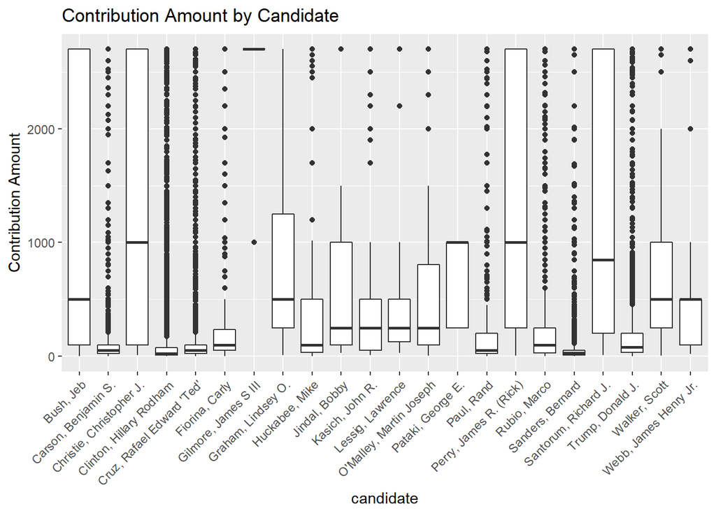

## Now let’s examine within parties

```
## # A tibble: 22 x 5
## # Groups:   party [2]
##         party                  cand_nm   sum_can  mean_can     n
##         <chr>                   <fctr>     <dbl>     <dbl> <int>
##  1 republican        Pataki, George E.   6000.00  666.6667     9
##  2 republican     Gilmore, James S III  11800.00 2360.0000     5
##  3   democrat         Lessig, Lawrence  20027.94  646.0626    31
##  4   democrat    Webb, James Henry Jr.  31090.16  545.4414    57
##  5 republican            Jindal, Bobby  42460.00  772.0000    55
##  6   democrat  O'Malley, Martin Joseph 139187.00  669.1683   208
##  7 republican       Graham, Lindsey O. 146487.00  996.5102   147
##  8 republican Christie, Christopher J. 269355.00 1432.7394   188
##  9 republican     Santorum, Richard J. 281288.20 1152.8205   244
## 10 republican           Huckabee, Mike 284820.76  404.0011   705
## # ... with 12 more rows
```

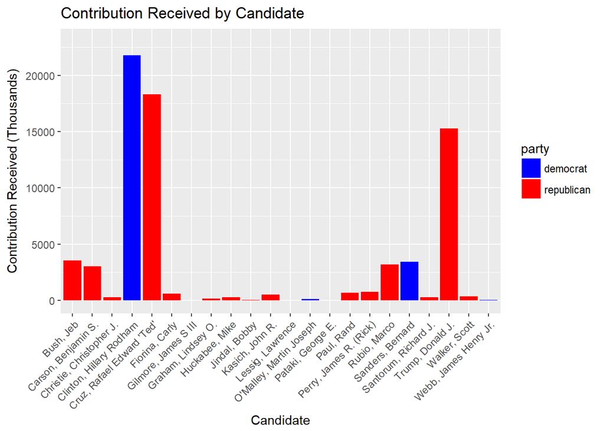

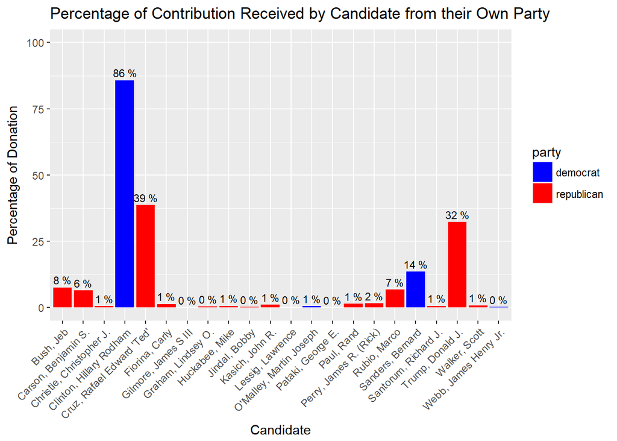

```
## [1] "Clinton, Hillary Rodham"   "Sanders, Bernard"
## [3] "Trump, Donald J."          "Rubio, Marco"
## [5] "Cruz, Rafael Edward 'Ted'"
```

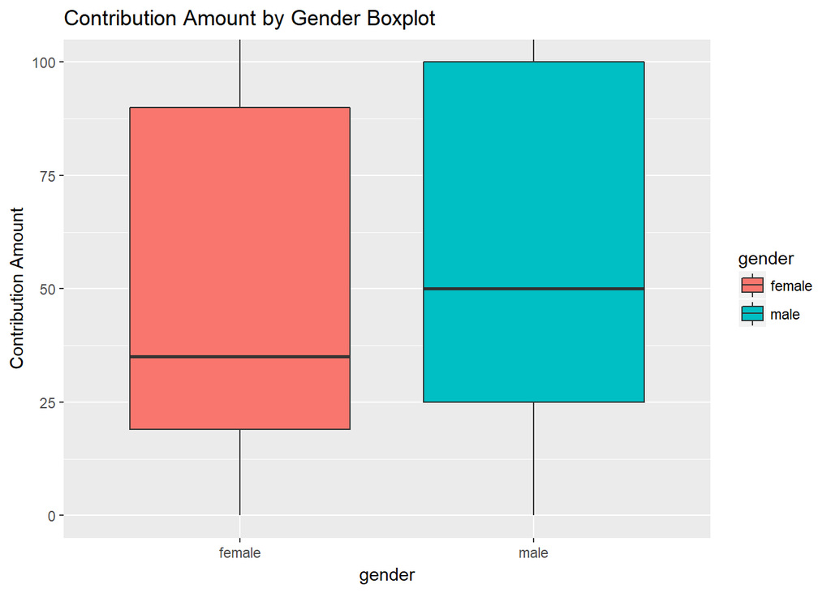

```
## ptx$gender: female
##    Min. 1st Qu.  Median    Mean 3rd Qu.    Max.
##    0.04   19.00   35.00  119.24   90.00 2700.00
## --------------------------------------------------------
## ptx$gender: male
##    Min. 1st Qu.  Median    Mean 3rd Qu.    Max.
##    0.12   25.00   50.00  160.52  100.00 2700.00
```

```
## # A tibble: 2 x 3
##   gender  sum_gen      n
##    <chr>    <dbl>  <int>
## 1 female 28983480 243066
## 2   male 43779684 272745
```

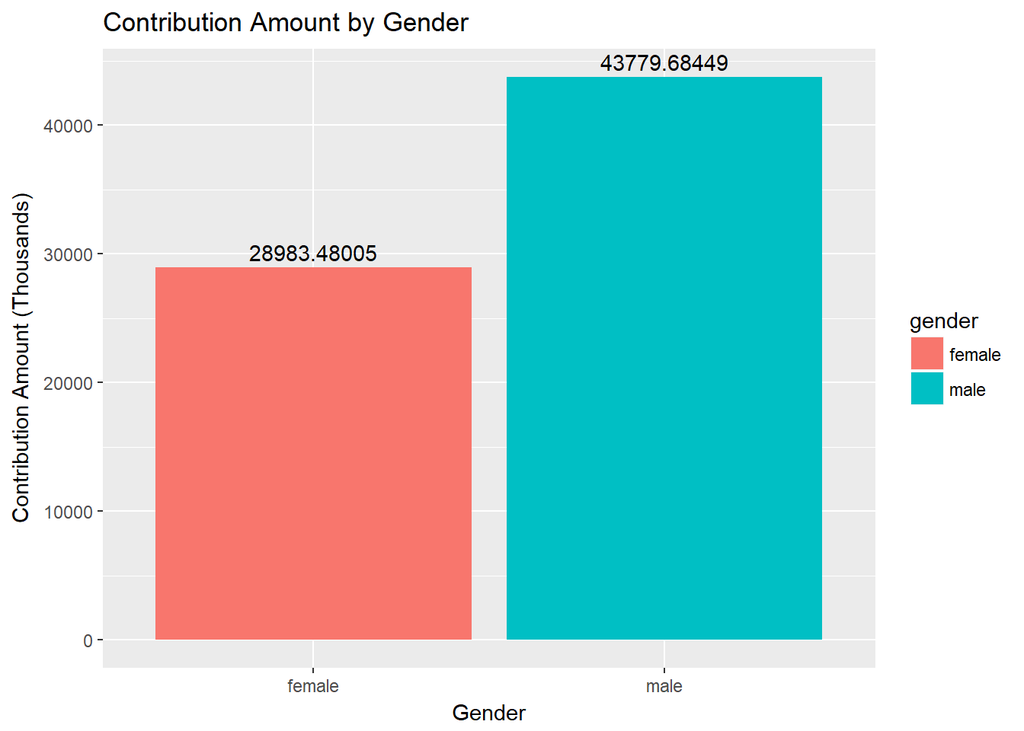

```
## # A tibble: 10 x 3
## # Groups:   cand_nm [?]
##                      cand_nm gender sum_gen_can
##                       <fctr>  <chr>       <dbl>
##  1   Clinton, Hillary Rodham female    11181372
##  2   Clinton, Hillary Rodham   male    10617491
##  3 Cruz, Rafael Edward 'Ted' female     6606053
##  4 Cruz, Rafael Edward 'Ted'   male    11689952
##  5              Rubio, Marco female     1081671
##  6              Rubio, Marco   male     2102038
##  7          Sanders, Bernard female     1250888
##  8          Sanders, Bernard   male     2182689
##  9          Trump, Donald J. female     4715652
## 10          Trump, Donald J.   male    10575717
```

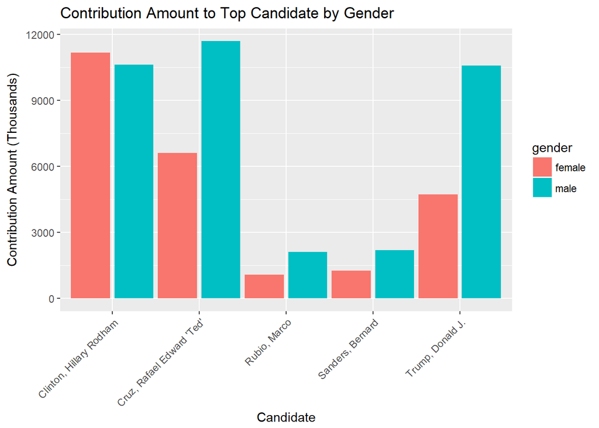

## How about total contribution amount and average contribution amount cross top 10 occupations?

```
## # A tibble: 10 x 4
##    contbr_occupation   sum_occu mean_occu      n
##                <ord>      <dbl>     <dbl>  <int>
##  1           RETIRED 14463581.2 106.39758 135939
##  2      NOT EMPLOYED  1115695.9  49.29074  22635
##  3          ATTORNEY  3970684.4 293.77659  13516
##  4         HOMEMAKER  3396748.8 327.93482  10358
##  5          ENGINEER  1178075.9 138.85855   8484
##  6         PHYSICIAN  1935789.1 244.63404   7913
##  7           TEACHER   445565.3  57.61123   7734
##  8             SALES   717011.8 105.16454   6818
##  9        CONSULTANT   935606.1 179.92425   5200
## 10         PROFESSOR   470172.9  97.62726   4816
```

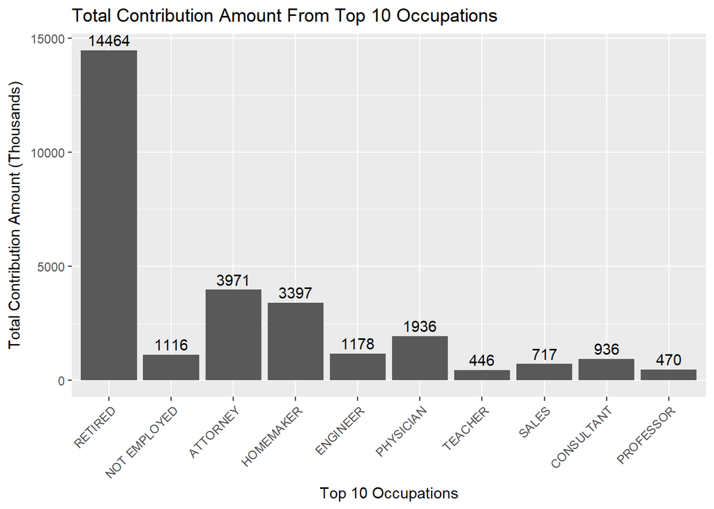

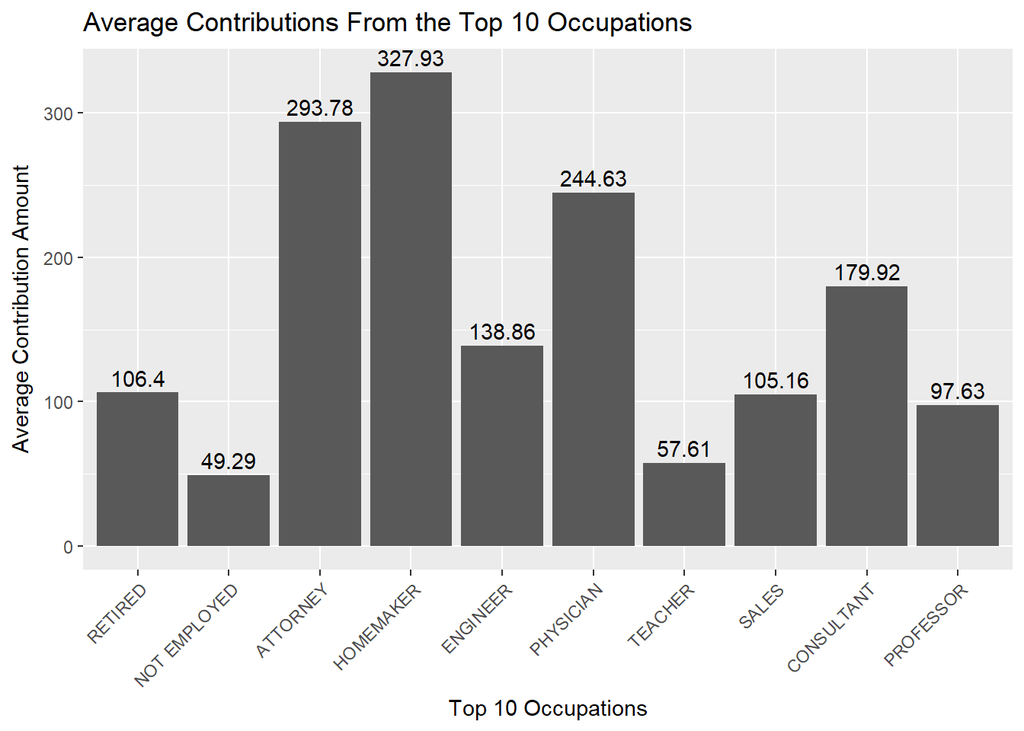

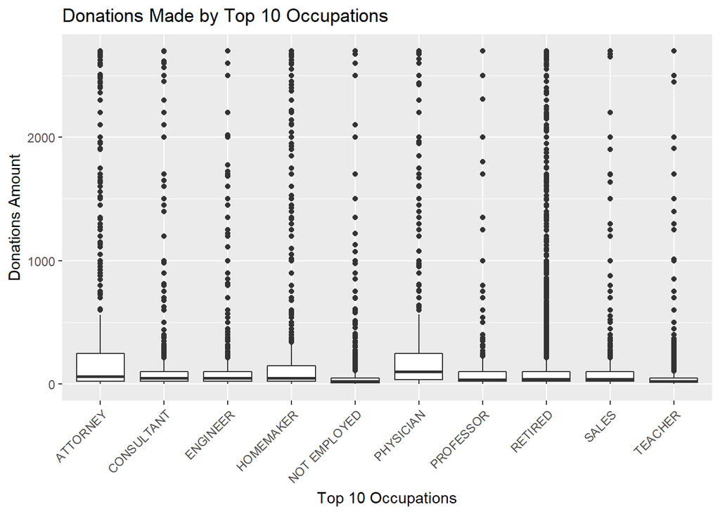

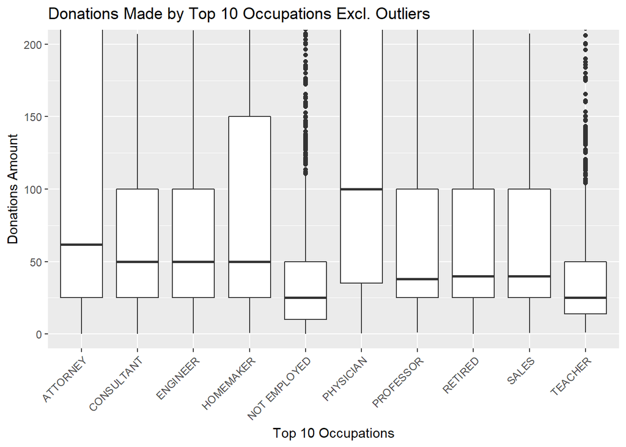

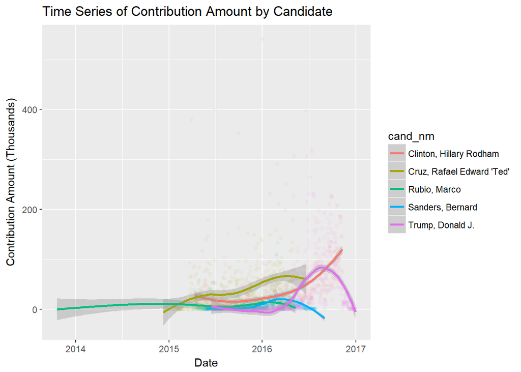

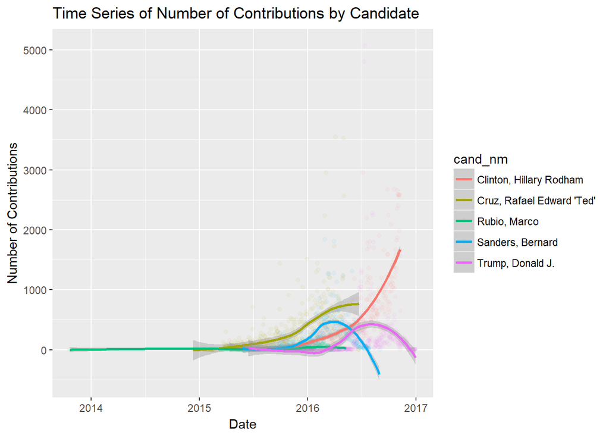

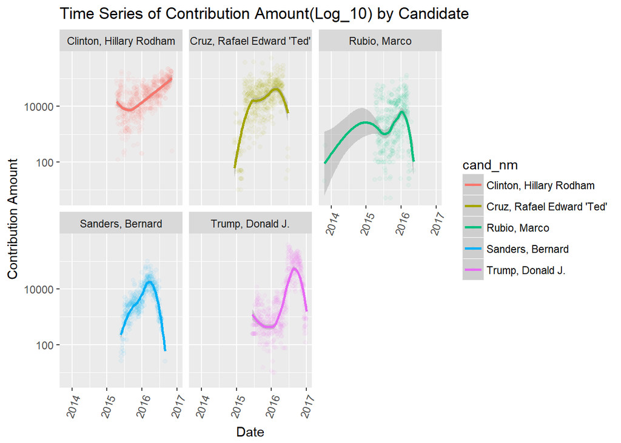

# Final Plots and Summaries

Most donations went to a few candidates. In Texas financial donations to the presidential campaign were distributed unevenly. Especially in Democrat, 86% of the donations for Democrat went to Hillary Clinton. “In the 2016 presidential election, it would appear, the question is not whether Democrats can turn Texas blue; it is whether Donald Trump will do so. … Polling has found him underperforming in a number of red states, and it is natural that Texas should be among them.”

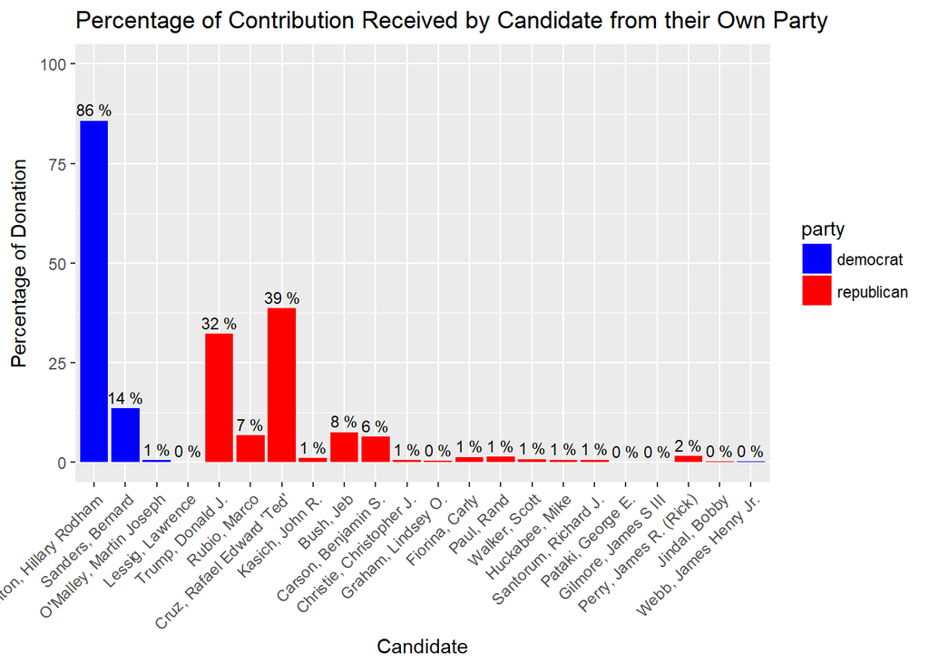

## Time Series of Top Candidates

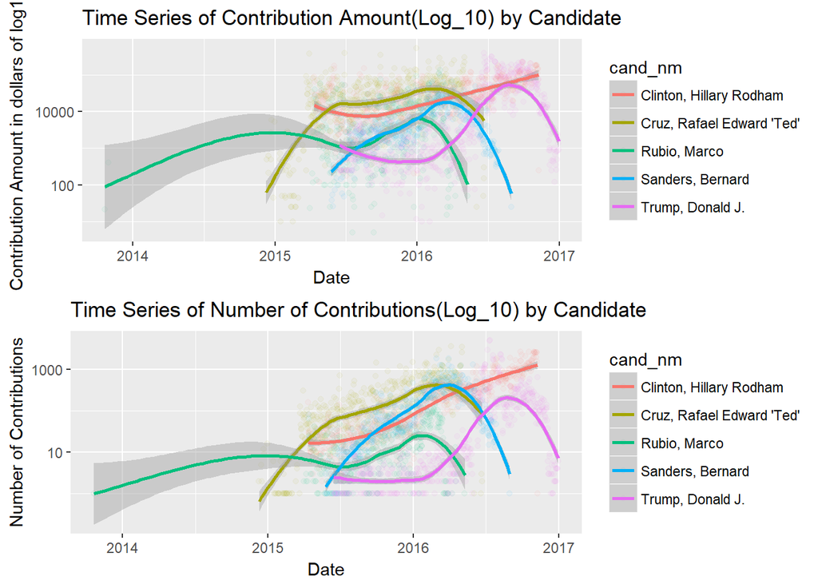

Hillary Clinton dominated the contribution amount and number of contributions donors.From the plots, it looks like Bernard Sanders and Donald Trump drastically reduced the contribution towards the end of elections and Hillary Clinton continued to contribute.

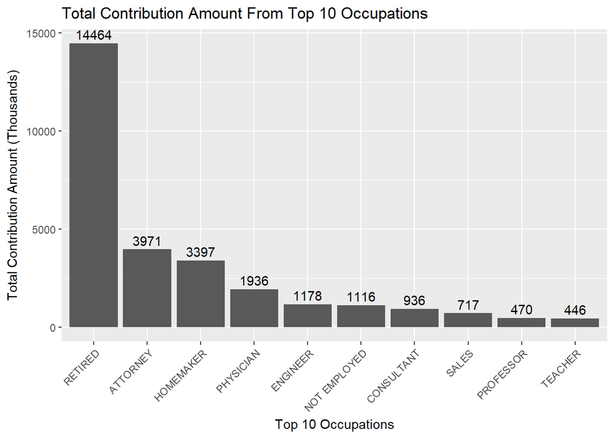

The top occupation that most generously contributed was ‘retired’. The total contribution across occupations differed substantially.

Tecahers and Professors contributed very less (surpising was that they contributed lesser than “not employed”)

# Challenges

The original dataset did not contain gender information, to analyze the relationship between gender and donations, I added gender column using R’s gender package which used to predict gender from donor’s first name. It was a challenge to learn and do R in general especially the ggplots as sometimes when proper fomatting is not done, nothing appears on the graphs.

The ggplot2 and dplyr packages are the most important packages for this project.

# Issues

Gender information was not there. Latitude and Longitude had to be added.

# Conclusion

By analyzing Texas financial donation data, I found several interesting characteristics:

It is no doubt that Texas is one of the red states although it was not much apparent in 2016 elections. Few candidates collected the most donations. We need to have the right political knowledge to know the exact situation. This analysis might prove out to be useful fo those who are abreast with the current political knowledge. Also, contribution is just one factor, there might be several other factors which influenced the elections.